# IODS course project

Juhana Rautavirta

## Chapter 1

> *“I’ve been waiting for IODS for ages!!”*

[**THIS IS A LINK TO MY GITHUB REPOSITORY**](https://github.com/JunzQ7/IODS-project)

| Languages | Programs |
| --- | --- |
| R | RStudio |
| Rmarkdown | GitHub |

# Chapter 2 - Linear Regression

*Describe the work you have done this week and summarize your learning.*

- Describe your work and results clearly.
- Assume the reader has an introductory course level understanding of writing and reading R code as well as statistical methods
- Assume the reader has no previous knowledge of your data or the more advanced methods you are using
1. Phase 1

```r
l2014 <- read.table("/home/juhana/Desktop/IODS-project/learning2014.txt", sep = ",", header = T)
str(l2014)
```

```
## 'data.frame':    166 obs. of  7 variables:
##  $ gender  : Factor w/ 2 levels "F","M": 1 2 1 2 2 1 2 1 2 1 ...
##  $ age     : int  53 55 49 53 49 38 50 37 37 42 ...
##  $ attitude: num  3.7 3.1 2.5 3.5 3.7 3.8 3.5 2.9 3.8 2.1 ...
##  $ deep    : num  3.58 2.92 3.5 3.5 3.67 ...
##  $ stra    : num  3.38 2.75 3.62 3.12 3.62 ...
##  $ surf    : num  2.58 3.17 2.25 2.25 2.83 ...
##  $ points  : int  25 12 24 10 22 21 21 31 24 26 ...
```

```r
head(l2014)
```

```
##   gender age attitude     deep  stra     surf points
## 1      F  53      3.7 3.583333 3.375 2.583333     25
## 2      M  55      3.1 2.916667 2.750 3.166667     12
## 3      F  49      2.5 3.500000 3.625 2.250000     24
## 4      M  53      3.5 3.500000 3.125 2.250000     10
## 5      M  49      3.7 3.666667 3.625 2.833333     22
## 6      F  38      3.8 4.750000 3.625 2.416667     21
```

This dataset is a modified dataset from its original data (http://www.helsinki.fi/~kvehkala/JYTmooc/JYTOPKYS3-data.txt). The dataset that I’m working with consists of 7 variables, which explain the answerers’ gender, age, attitude towards statistics, points of their exam (Course: Johdatus yhteiskuntatilastotieteeseen, syksy 2014) and their learning style.

2. Phase 2

```r
summary(l2014)
```

```
##  gender       age           attitude          deep            stra
##  F:110   Min.   :17.00   Min.   :1.400   Min.   :1.583   Min.   :1.250
##  M: 56   1st Qu.:21.00   1st Qu.:2.600   1st Qu.:3.333   1st Qu.:2.625
##          Median :22.00   Median :3.200   Median :3.667   Median :3.188
##          Mean   :25.51   Mean   :3.143   Mean   :3.680   Mean   :3.121
##          3rd Qu.:27.00   3rd Qu.:3.700   3rd Qu.:4.083   3rd Qu.:3.625
##          Max.   :55.00   Max.   :5.000   Max.   :4.917   Max.   :5.000
##       surf           points
##  Min.   :1.583   Min.   : 7.00
##  1st Qu.:2.417   1st Qu.:19.00
##  Median :2.833   Median :23.00
##  Mean   :2.787   Mean   :22.72
##  3rd Qu.:3.167   3rd Qu.:27.75
##  Max.   :4.333   Max.   :33.00
```

Here we have the summaries of the variables in this data. It is clear that the female gender is represented quite much better than the male gender (F/M = 110/56). The ages are distributed with a median of 22. Since the oldest answerer seems to be 55 years old, it is good to focus on median instead of mean.

```r
library(ggplot2)
library(GGally)
```

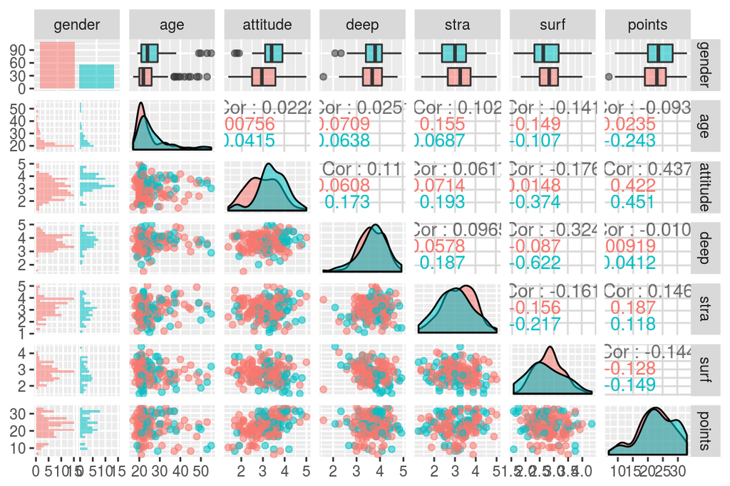

```r
ggpairs(l2014, mapping = aes(col = gender, alpha = 0.3), lower = list(combo = wrap("facethist", bins = 20)))
```

From this plotmatrix we can see the distributions and the correlation between the variables more cleary.

Let us first focus on the correlation between the exam points with other variables. The biggest correlation seems to be with the attitude towards statistics, which is not very surprising. There is also a considerable negative correlation between the age of male students and their points, whereas the age of female students have a tiny positive correlation with their points. From the two learning methods, deep learning has almost none correlation with the points and the strategic learning has got a noticeable correlation of 0.15.

The biggest difference between the two genders is found from the attitude towards statistics, where men tend to score better. Another considerable difference can be found from the surface questions.

3. Phase 3

```r
summary(lm(points~age+attitude+stra, data=l2014))
```

```
##
## Call:
## lm(formula = points ~ age + attitude + stra, data = l2014)
##
## Residuals:
##      Min       1Q   Median       3Q      Max
## -18.1149  -3.2003   0.3303   3.4129  10.7599
##
## Coefficients:
##             Estimate Std. Error t value Pr(>|t|)
## (Intercept) 10.89543    2.64834   4.114 6.17e-05 ***
## age         -0.08822    0.05302  -1.664   0.0981 .
## attitude     3.48077    0.56220   6.191 4.72e-09 ***
## stra         1.00371    0.53434   1.878   0.0621 .
## ---
## Signif. codes:  0 '***' 0.001 '**' 0.01 '*' 0.05 '.' 0.1 ' ' 1
##
## Residual standard error: 5.26 on 162 degrees of freedom
## Multiple R-squared:  0.2182, Adjusted R-squared:  0.2037
## F-statistic: 15.07 on 3 and 162 DF,  p-value: 1.07e-08
```

Here we see a summary of a fitted regression model with three explanatory variables (age$=x_1$, attitud$=x_2$e and strategic learning $=x_3$) and the target value (points$=y$). This statistical test is testing how well the target value ($y$) corresponds to the explanatory variables ($x_1, x_2, x_3$), if we assume that there is a linear regression between the variables, so that $y = \alpha + \beta_1x_1 + \beta_2x_2 + \beta_3x_3 + \epsilon$, where $\epsilon$ is assumed to be a normally distributed error variable with a mean of 0.

In this particular model we see that $\alpha = 10.90, \beta_1 = -0.090, \beta_2=3.50, \beta_3 = 1.00$. Since $\beta_2=3.50$ is statistically the only significant result, we might remove the variables $x_1$ and $x_3$, and fit the model again with only one explanatory variable. So we get:

```r
summary(lm(points~attitude,data=l2014))
```

```
##
## Call:
## lm(formula = points ~ attitude, data = l2014)
##
## Residuals:
##      Min       1Q   Median       3Q      Max
## -16.9763  -3.2119   0.4339   4.1534  10.6645
##
## Coefficients:
##             Estimate Std. Error t value Pr(>|t|)
## (Intercept)  11.6372     1.8303   6.358 1.95e-09 ***
## attitude      3.5255     0.5674   6.214 4.12e-09 ***
## ---
## Signif. codes:  0 '***' 0.001 '**' 0.01 '*' 0.05 '.' 0.1 ' ' 1
##
## Residual standard error: 5.32 on 164 degrees of freedom
## Multiple R-squared:  0.1906, Adjusted R-squared:  0.1856
## F-statistic: 38.61 on 1 and 164 DF,  p-value: 4.119e-09
```

4. Phase 4

Another important value in this summary is 4.12e-09. It means that if we have set a null hyphotesis $H_0:\beta=0$, meaning that there is no correlation between points an attitude, the probability to get results like this. When we get a value of this size, it gives as a reason to reject the null hyphotesis and claim that there is a statistically significant correlation between attitude and points.

A value called multiple R-squared can also be found from the summary. This value basicly tells how well the model fits with our data and it is always a value between 0 and 1. The closer the value is to 1, the better our model fits the data. In this case the value is 0.1906, which indicates that our model does not fit the data very well.

As we can see from the following plot, occasionally the observation are quite far away from our regression model.

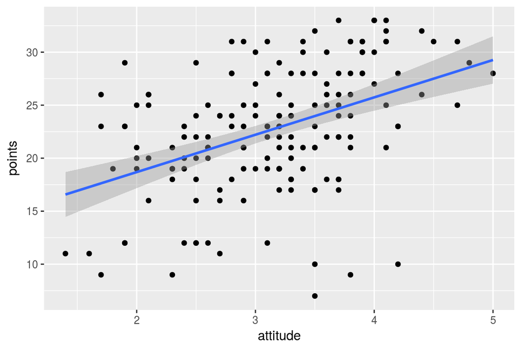

```r
qplot(attitude, points, data = l2014) + geom_smooth(method = "lm")
```

5. Phase 5

In the following series of plots we can see some analysis of the residuals. The first picture shows the residuals against our fitted model. It seems that our residuals are spread out in quite an even way.

Let us remember the error variable $\epsilon$ in our model. The assumption was that it is normally distributed: $\epsilon\sim N(0,\sigma²)$). In the second picture (“QQ-plot”) we see that if we standardize the errors, it fits our model very beautifully! This indicates that the residuals really are normally distributed. The last plot shows the leverage in our data, which means that how much impact single obsertavions have on the model. In this scenario, no point has higher leverage value than 0.05, which is very little.

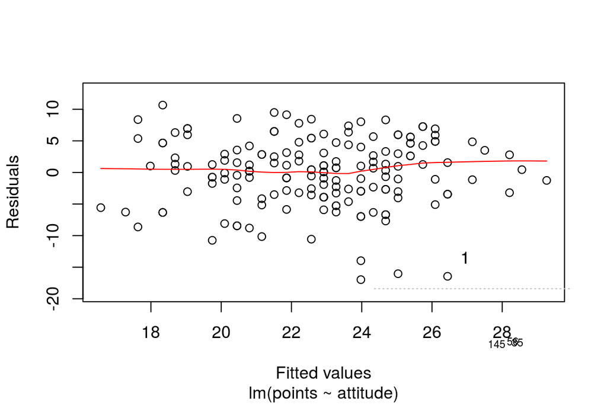

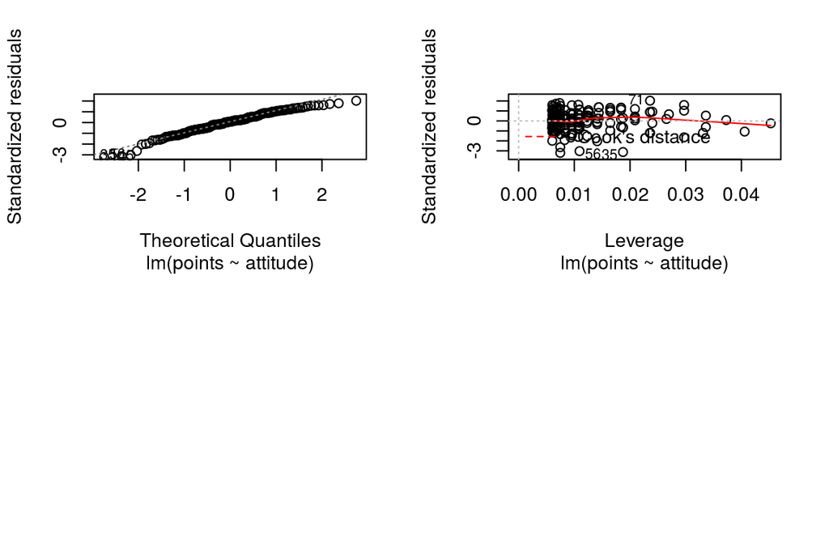

```r
plot(lm(points~attitude, data=l2014), which = c(1,2,5), par(mfrow=c(2,2)) )
```

# Chapter 3 - Logistic Regression

```r
alc <- read.table("/home/juhana/Desktop/IODS-project/data/alc.csv", sep = ",", header = T)
library(ggplot2)
library(dplyr)
```

In this data we are interested in the relationships between high/low alcohol consumption and other variables. Let us choose choose the variables to study on to be these ones: “famrel” (quality of family relationships), “famsup” (family educational support), “goout” (going out with friends) and “Pstatus” (parents’ cohabitation status).

My hyphotesis is that every variable from the four chosen variable has an interesting statistical relationship with alcohol consumption. Let us see if it is true!

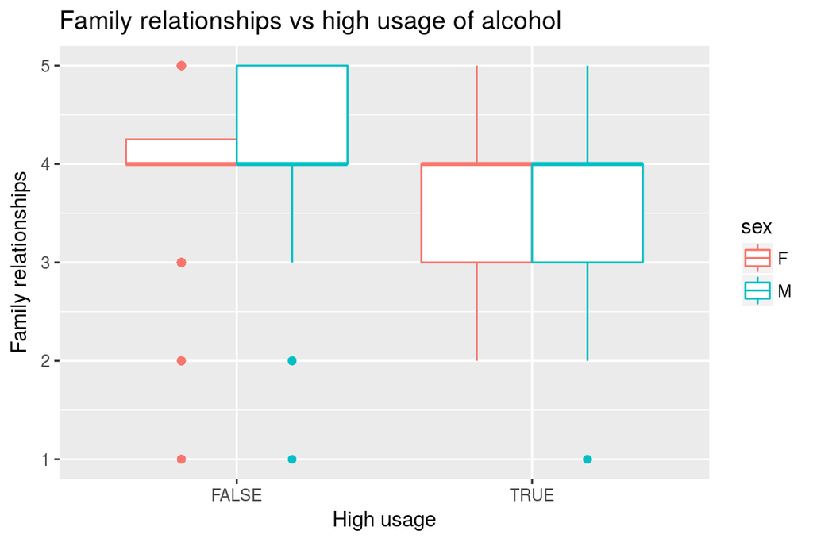

```r
g1 <- ggplot(alc, aes(x=high_use, y=famrel, col = sex))
g1 + geom_boxplot() + ylab("Family relationships")+ xlab("High usage") + ggtitle("Family relationships vs high usage of alcohol")
```

As we can see from this boxplot, high usage of alcohol seems to to weaken the students’ family relationships (since 1 - very bad <-> 5 - excellent).

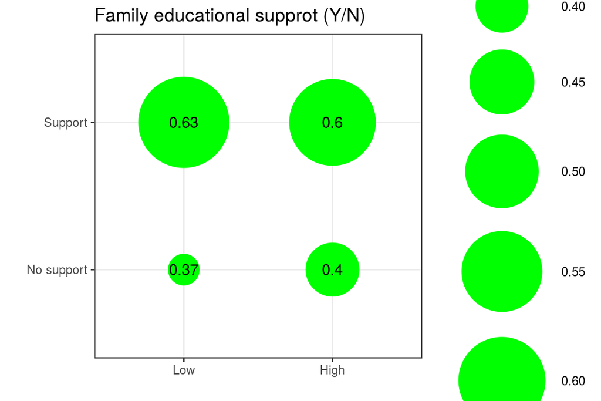

```r
values <- rep(x = 0, 4)
values[1]<- sum((!alc$high_use) & (alc$famsup == "no"))
values[2]<- sum((alc$high_use) & (alc$famsup == "no"))
values[3]<- sum((!alc$high_use) & (alc$famsup == "yes"))
values[4]<- sum((alc$high_use) & (alc$famsup == "yes"))
values[c(1,3)] = values[c(1,3)]/sum(!alc$high_use)
values[c(2,4)] = values[c(2,4)]/sum(alc$high_use)
df <- expand.grid(c( "Low","High"), c("No support", "Support"))
g2 <- ggplot(df, aes(x = Var1, y=Var2)) + geom_point(aes(size = values), colour = "green") + theme_bw() + xlab("") + ylab("")
g2 + scale_size_continuous(range=c(10,30)) +geom_text(aes(label = round(values, digits = 2))) + ggtitle("Family educational supprot (Y/N)")
```

Here we can see the persentages of students who get educational support from family sorted by the usage of alcohol. There is a slight difference between high and low usage, but the difference could be much more!

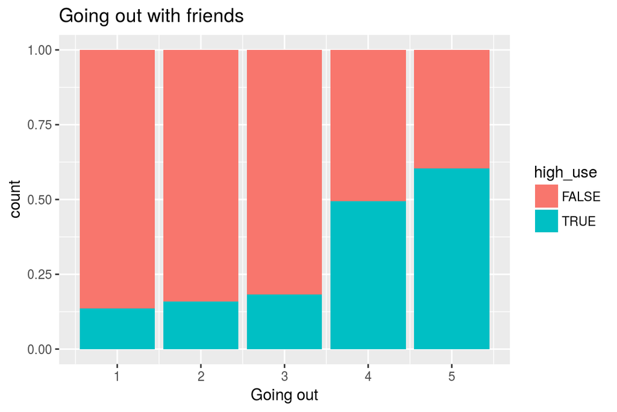

```r
f1 <- ggplot(alc, aes(goout))
f1 + geom_bar(aes(fill = high_use), position = "fill") + xlab("Going out") + ggtitle("Going out with friends")
```

Interestingly in this barplot we can see that clearly students who use high amount of alcohol thend to go out with friends much more!

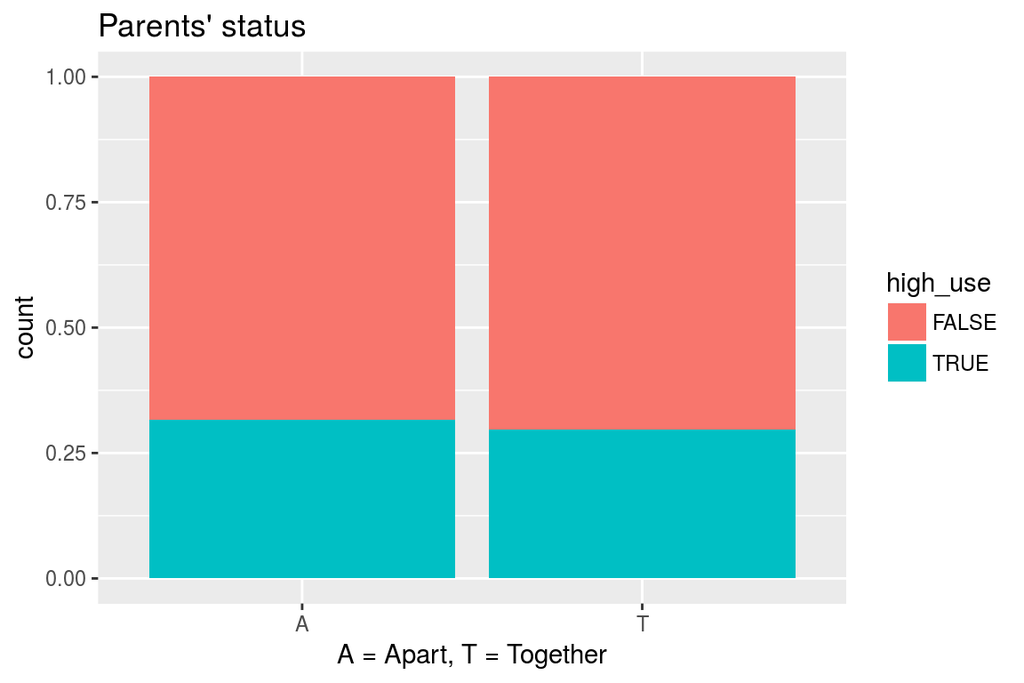

```r
d1 <- ggplot(alc, aes(Pstatus))
d1 + geom_bar(aes(fill = high_use), position = "fill") + xlab("A = Apart, T = Together") + ggtitle("Parents' status")
```

When exploring the relationship between parents cohabitation status and high alcohol usage, we see that in families where parents are living together, the usage of alcohol is smaller than in families where parents are living together. However, the difference is somewhat small.

Next

```r
model <- glm(high_use ~ famrel + famsup + goout + Pstatus, data = alc, family = "binomial")

summary(model)
```

```
##
## Call:
## glm(formula = high_use ~ famrel + famsup + goout + Pstatus, family = "binomial",
##     data = alc)
##
## Deviance Residuals:
##     Min       1Q   Median       3Q      Max
## -1.5852  -0.7814  -0.5476   1.0145   2.3801
##
## Coefficients:
##             Estimate Std. Error z value Pr(>|z|)
## (Intercept) -1.85630    0.71236  -2.606  0.00916 **
## famrel      -0.36720    0.13404  -2.740  0.00615 **
## famsupyes   -0.15800    0.24886  -0.635  0.52549
## goout        0.79197    0.11830   6.694 2.17e-11 ***
## PstatusT    -0.08061    0.40154  -0.201  0.84090
## ---
## Signif. codes:  0 '***' 0.001 '**' 0.01 '*' 0.05 '.' 0.1 ' ' 1
##
## (Dispersion parameter for binomial family taken to be 1)
##
##     Null deviance: 465.68  on 381  degrees of freedom
## Residual deviance: 407.67  on 377  degrees of freedom
## AIC: 417.67
##
## Number of Fisher Scoring iterations: 4
```

```r
OR <- coef(model) %>% exp
CI <- confint(model) %>% exp
cbind(OR, CI)
```

```
##                    OR      2.5 %    97.5 %
## (Intercept) 0.1562491 0.03743733 0.6178607
## famrel      0.6926689 0.53108709 0.8997772
## famsupyes   0.8538490 0.52469521 1.3945715
## goout       2.2077461 1.76184084 2.8042253
## PstatusT    0.9225553 0.42698643 2.0847126
```

Here we have an awful amount of coefficients and values from the logistic regression model. A long story short: my orginal hyphotesis that with every explanatory variable we can confidently predict the usage of alcohol, can be rejected. This is because only family relationship and going out with friends seem to be factors that have a statistically significant relationship with the usage of alcohol.

```r
model2 <- glm(high_use ~ famrel + goout, data = alc, family = "binomial")
probabilities <- predict(model2, type = "response")
alc <- mutate(alc, probability = probabilities)
alc <- mutate(alc, prediction = probabilities>0.5)
table(high_use = alc$high_use, prediction = alc$prediction)
```

```
##         prediction
## high_use FALSE TRUE
##    FALSE   243   25
##    TRUE     68   46
```

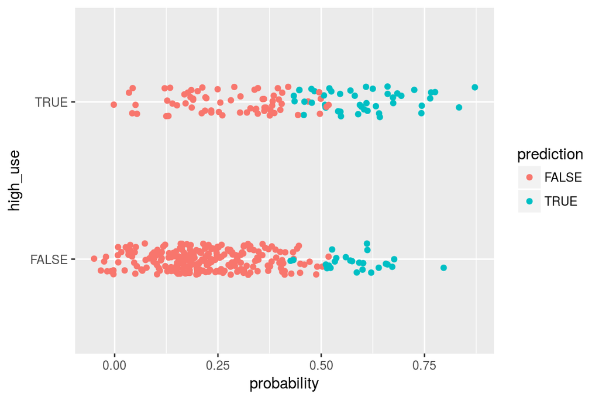

```r
d2 <- ggplot(alc, aes(x = probability, y = high_use, col = prediction))
d2 + geom_point(position = position_jitter(w=0.1,h=0.1))
```

From this 2x2 cross tabulation we can see that from all the $382$ observations $68+25=93$ were predicted wrongly, meaning that we have a training error of $\frac{93}{382} = 0.243$.

# Chapter 5 - Dimensionality reduction techniques

```r
setwd("/home/juhana/Desktop/IODS-project/data")
human <- read.csv("/home/juhana/Desktop/IODS-project/data/human.csv", sep = ",", header = T, row.names = 1)
library(ggplot2)
library(dplyr)
library(stringr)
library(tidyr)
library(GGally)
```

Let us explore the structure and the dimensions of the loaded data:

```r
str(human)
```

```
## 'data.frame':    155 obs. of  8 variables:
##  $ Edu2.FM  : num  1.007 0.997 0.983 0.989 0.969 ...
##  $ Labo.FM  : num  0.891 0.819 0.825 0.884 0.829 ...
##  $ Edu.Exp  : num  17.5 20.2 15.8 18.7 17.9 16.5 18.6 16.5 15.9 19.2 ...
##  $ Life.Exp : num  81.6 82.4 83 80.2 81.6 80.9 80.9 79.1 82 81.8 ...
##  $ GNI      : int  64992 42261 56431 44025 45435 43919 39568 52947 42155 32689 ...
##  $ Mat.Mor  : int  4 6 6 5 6 7 9 28 11 8 ...
##  $ Ado.Birth: num  7.8 12.1 1.9 5.1 6.2 3.8 8.2 31 14.5 25.3 ...
##  $ Parli.F  : num  39.6 30.5 28.5 38 36.9 36.9 19.9 19.4 28.2 31.4 ...
```

```r
dim(human)
```

```
## [1] 155   8
```

This dataset is about GNI:s and other variables in 155 different countries. There are 8 variables in all.

Let us see a graphical overview of the data and a summary of the variables:

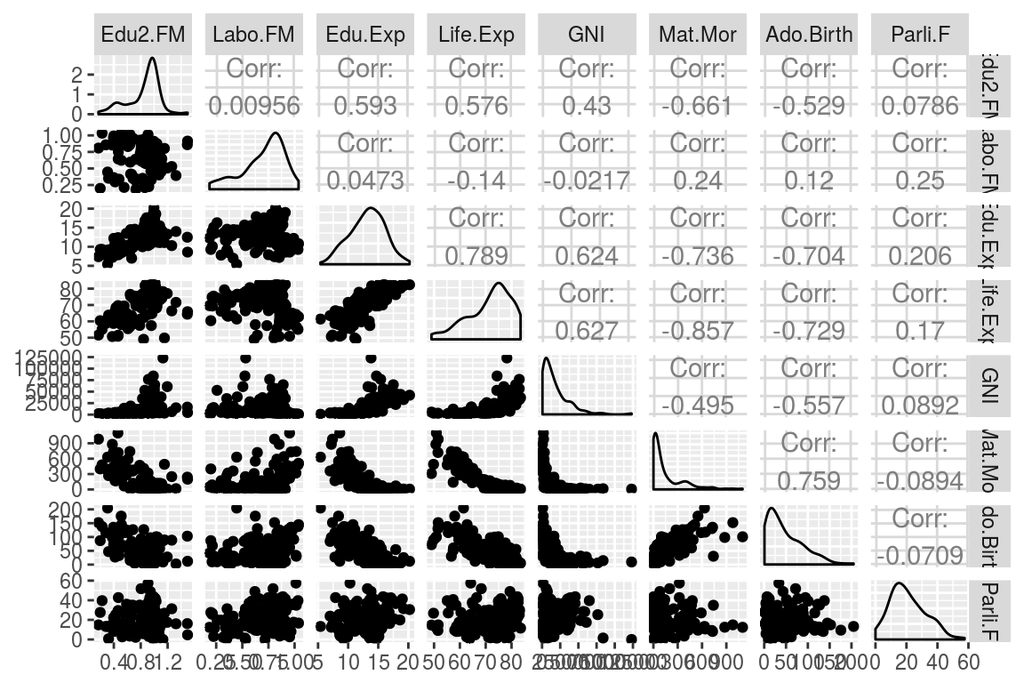

```r
ggpairs(human)
```

```r
summary(human)
```

```
##     Edu2.FM          Labo.FM          Edu.Exp         Life.Exp
##  Min.   :0.1717   Min.   :0.1857   Min.   : 5.40   Min.   :49.00
##  1st Qu.:0.7264   1st Qu.:0.5984   1st Qu.:11.25   1st Qu.:66.30
##  Median :0.9375   Median :0.7535   Median :13.50   Median :74.20
##  Mean   :0.8529   Mean   :0.7074   Mean   :13.18   Mean   :71.65
##  3rd Qu.:0.9968   3rd Qu.:0.8535   3rd Qu.:15.20   3rd Qu.:77.25
##  Max.   :1.4967   Max.   :1.0380   Max.   :20.20   Max.   :83.50
##       GNI            Mat.Mor         Ado.Birth         Parli.F
##  Min.   :   581   Min.   :   1.0   Min.   :  0.60   Min.   : 0.00
##  1st Qu.:  4198   1st Qu.:  11.5   1st Qu.: 12.65   1st Qu.:12.40
##  Median : 12040   Median :  49.0   Median : 33.60   Median :19.30
##  Mean   : 17628   Mean   : 149.1   Mean   : 47.16   Mean   :20.91
##  3rd Qu.: 24512   3rd Qu.: 190.0   3rd Qu.: 71.95   3rd Qu.:27.95
##  Max.   :123124   Max.   :1100.0   Max.   :204.80   Max.   :57.50
```

As you can see, there is a considerable correlation between many variables. What is also interesting is that the variable Edu.Exp seems to be almost normally distributed, whereas the Mat.Mor and GNI variables seem to be exponentially distributed.

Next we will perform a principal component analysis!

```r
pca_human <- prcomp(human)
summary(pca_human)
```

```
## Importance of components:
##                              PC1      PC2   PC3   PC4   PC5   PC6    PC7
## Standard deviation     1.854e+04 185.5219 25.19 11.45 3.766 1.566 0.1912
## Proportion of Variance 9.999e-01   0.0001  0.00  0.00 0.000 0.000 0.0000
## Cumulative Proportion  9.999e-01   1.0000  1.00  1.00 1.000 1.000 1.0000
##                           PC8
## Standard deviation     0.1591
## Proportion of Variance 0.0000
## Cumulative Proportion  1.0000
```

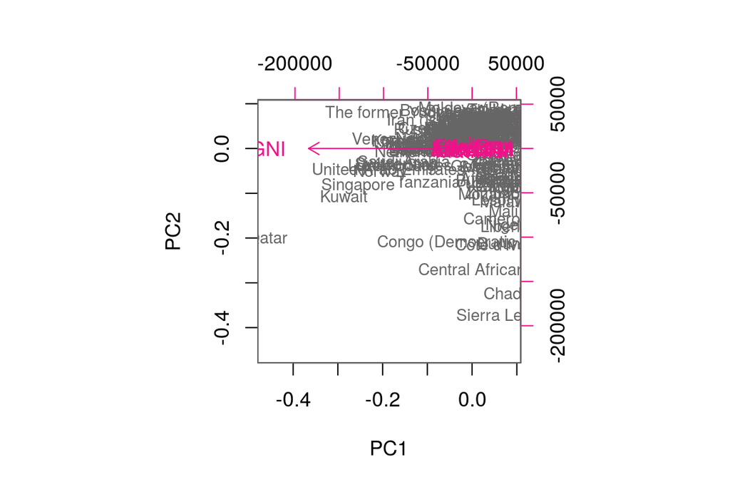

```r
biplot(pca_human, choices = 1:2, cex = c(0.8,1),col = c("grey40", "deeppink2"))
```

And now we do the same with standardized variables!

```r
human_std <- scale(human)
summary(human_std)
```

```
##     Edu2.FM           Labo.FM           Edu.Exp           Life.Exp
##  Min.   :-2.8189   Min.   :-2.6247   Min.   :-2.7378   Min.   :-2.7188
##  1st Qu.:-0.5233   1st Qu.:-0.5484   1st Qu.:-0.6782   1st Qu.:-0.6425
##  Median : 0.3503   Median : 0.2316   Median : 0.1140   Median : 0.3056
##  Mean   : 0.0000   Mean   : 0.0000   Mean   : 0.0000   Mean   : 0.0000
##  3rd Qu.: 0.5958   3rd Qu.: 0.7350   3rd Qu.: 0.7126   3rd Qu.: 0.6717
##  Max.   : 2.6646   Max.   : 1.6632   Max.   : 2.4730   Max.   : 1.4218
##       GNI             Mat.Mor          Ado.Birth          Parli.F
##  Min.   :-0.9193   Min.   :-0.6992   Min.   :-1.1325   Min.   :-1.8203
##  1st Qu.:-0.7243   1st Qu.:-0.6496   1st Qu.:-0.8394   1st Qu.:-0.7409
##  Median :-0.3013   Median :-0.4726   Median :-0.3298   Median :-0.1403
##  Mean   : 0.0000   Mean   : 0.0000   Mean   : 0.0000   Mean   : 0.0000
##  3rd Qu.: 0.3712   3rd Qu.: 0.1932   3rd Qu.: 0.6030   3rd Qu.: 0.6127
##  Max.   : 5.6890   Max.   : 4.4899   Max.   : 3.8344   Max.   : 3.1850
```

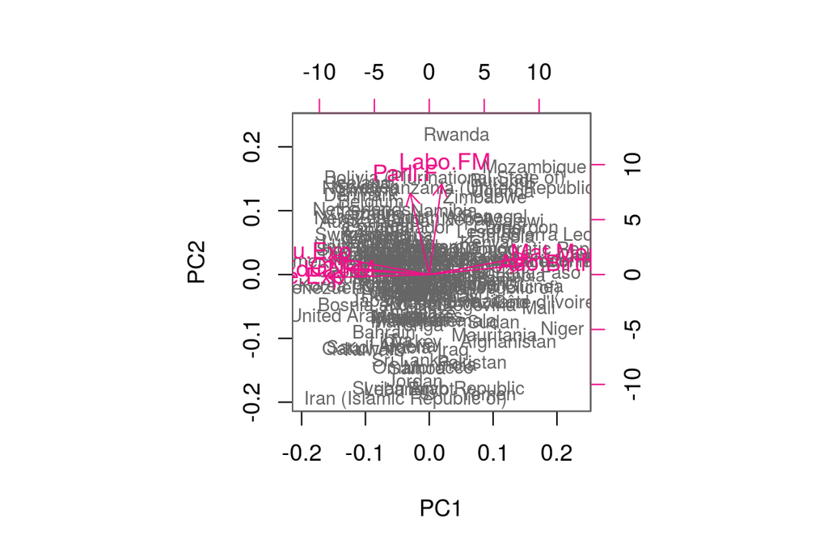

```r
pca_human <- prcomp(human_std)
biplot(pca_human, choices = 1:2, cex = c(0.8,1),col = c("grey40", "deeppink2"))
```